# Day3_sec_ds_lv3_prob2_prob-Copy2

## 단계 3-4

prob3를 학습용 80%, 그 외 20%는 테스트용으로 나누어 prob3_train, prob3_test로 한다.

**함수가이드**

sklearn.model_selection.train_test_split, random_state=123

문제 지시사항 외 Default 값 사용

```python
from sklearn.model_selection import train_test_split

df_prob3_train, df_prob3_test = train_test_split(df_prob3, train_size=0.8, random_state=123)
```

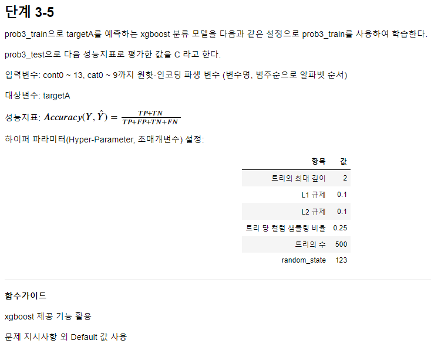

```python
Image('3-4.png')
```

```python
import xgboost as xgb
from sklearn.metrics import accuracy_score# 𝐴𝑐𝑐𝑢𝑟𝑎𝑐𝑦

X_xgb = cont_cols + dum_cols
print('X_xgb = ', X_xgb)

clf_xgb = xgb.XGBClassifier(
    max_depth=2, # 트리의 최대 깊이: 2
    reg_alpha=0.1, # L1 규제: 0.1
    reg_lambda=0.1, # L2 규제: 0.1
    colsample_bytree=0.25, # 트리 당 컬럼 샘플링 비율: 0.25
    n_estimators=500, # 트리의 수: 500
    random_state=123, # random_state: 123
)

clf_xgb.fit(df_prob3_train[X_xgb], df_prob3_train['targetA'])
```

```
X_xgb =  ['cont0', 'cont1', 'cont2', 'cont3', 'cont4', 'cont5', 'cont6', 'cont7', 'cont8', 'cont9', 'cont10', 'cont11', 'cont12', 'cont13', 'cat0_A', 'cat0_B', 'cat1_A', 'cat1_B', 'cat2_A', 'cat2_B', 'cat3_A', 'cat3_C', 'cat3_D', 'cat4_B', 'cat4_C', 'cat5_A', 'cat5_B', 'cat5_C', 'cat5_D', 'cat6_A', …
```

```
XGBClassifier(base_score=0.5, booster='gbtree', colsample_bylevel=1,
              colsample_bytree=0.25, gamma=0, learning_rate=0.1,
              max_delta_step=0, max_depth=2, min_child_weight=1, missing=None,
              n_estimators=500, n_jobs=1, nthread=None,
              objective='binary:logistic', random_state=123, reg_alpha=0.1,
              reg_lambda=0.1, scale_pos_weight=1, seed=None, silent=True,
              subsample=1)
```

```python
df_prob3_train['targetA'].value_counts(normalize=True).max()
```

```
0.5531099518459069
```

```python
C = accuracy_score(df_prob3_test['targetA'], clf_xgb.predict(df_prob3_test[X_xgb]))
(
    C,
    accuracy_score(df_prob3_train['targetA'], clf_xgb.predict(df_prob3_train[X_xgb]))
)
```

```
(0.6547351524879614, 0.6661918138041734)
```

```python
C, round(C, 3)
```

```
(0.6547351524879614, 0.655)
```

C 를 소수점 넷째 자리에서 반올림하여 셋째 자리까지 출력하라.

**0.655**

```python
# 3-4 ~ 3-6 정리

'''
이 코드는 `XGBClassifier`를 사용하여 이진 분류 모델을 학습시키고, 훈련 데이터와 테스트 데이터에 대한 예측 정확도를 계산합니다.

### 1. 데이터 분할
- `train_test_split`을 사용하여 `df_prob3` 데이터프레임을 80%의 훈련 데이터 (`df_prob3_train`)와
    20%의 테스트 데이터 (`df_prob3_test`)로 분할합니다.

### 2. 독립 변수 설정
- `X_xgb`는 모델 학습에 사용할 독립 변수들의 리스트입니다.
- `cont_cols`는 연속형 변수들의 리스트이고, `dum_cols`는 원-핫 인코딩된 범주형 변수들의 리스트입니다.
- 이 두 리스트를 결합하여 최종 독립 변수 리스트를 생성합니다.

### 3. XGBoost 분류기 설정 및 학습
- `max_depth=2`: 트리의 최대 깊이를 2로 설정하여 모델의 복잡도를 제어합니다.
- `reg_alpha=0.1`: L1 규제를 0.1로 설정하여 모델의 가중치 일부를 0으로 만듭니다.
- `reg_lambda=0.1`: L2 규제를 0.1로 설정하여 가중치의 크기를 제한합니다.
- `colsample_bytree=0.25`: 각 트리를 구성할 때 샘플링할 컬럼의 비율을 0.25로 설정합니다.
- `n_estimators=500`: 500개의 트리를 사용하여 모델을 학습시킵니다.
- `random_state=123`: 난수 생성 시드를 설정하여 결과의 재현성을 보장합니다.

- `clf_xgb.fit`을 사용하여 `df_prob3_train` 데이터프레임의 독립 변수(`X_xgb`)와
    종속 변수(`targetA`)를 사용하여 모델을 학습시킵니다.

### 4. 훈련 데이터의 클래스 불균형 확인
- `value_counts(normalize=True)`를 사용하여 `targetA`의 클래스 분포를 확인합니다.
- `.max()`를 사용하여 가장 빈번한 클래스의 비율을 반환합니다.
- 이는 클래스 불균형 정도를 확인하기 위한 것입니다.

### 5. 테스트 데이터에 대한 예측 정확도 계산
- `clf_xgb.predict`을 사용하여 테스트 데이터의 독립 변수(`X_xgb`)를 기반으로 `targetA` 값을 예측합니다.
- `accuracy_score`를 사용하여 실제 `targetA` 값과 예측된 `targetA` 값 간의 정확도를 계산하고, 이를 변수 `C`에 저장합니다.

### 6. 결과 반환
(
    C,
    accuracy_score(df_prob3_train['targetA'],
                    clf_xgb.predict(df_prob3_train[X_xgb]))
)
- `accuracy_score`를 사용하여 훈련 데이터의 실제 `targetA` 값과 예측된 `targetA` 값 간의 정확도를 계산합니다.
- 결과는 튜플 형태로 반환됩니다. 첫 번째 값은 테스트 데이터의 정확도(`C`), 두 번째 값은 훈련 데이터의 정확도입니다.

### 전체 코드 동작 요약

1. 데이터 분할:
    `df_prob3`를 80% 훈련 데이터와 20% 테스트 데이터로 분할합니다.
2. 독립 변수 설정:
    연속형 변수들과 원-핫 인코딩된 범주형 변수들을 결합하여 독립 변수 리스트를 만듭니다.
3. XGBoost 분류기 설정 및 학습:
    XGBoost 분류기를 설정하고 훈련 데이터를 사용하여 학습시킵니다.
4. 클래스 불균형 확인: 훈련 데이터에서 가장 빈번한 클래스의 비율을 확인합니다.
5. 예측 정확도 계산: 테스트 데이터와 훈련 데이터에 대해 예측을 수행하고 정확도를 계산합니다.
6. 결과 반환: 테스트 데이터와 훈련 데이터의 정확도를 튜플 형태로 반환합니다.

이 과정은 모델의 성능을 평가하는 데 사용됩니다.
테스트 데이터에 대한 정확도는 모델의 일반화 성능을 나타내고, 훈련 데이터에 대한 정확도는
모델이 훈련 데이터에 얼마나 잘 맞는지를 나타냅니다. 두 값의 비교를 통해
모델이 과적합(overfitting)되었는지 또는 과소적합(underfitting)되었는지를 판단할 수 있습니다.
'''
print('')
```

# 문제 4

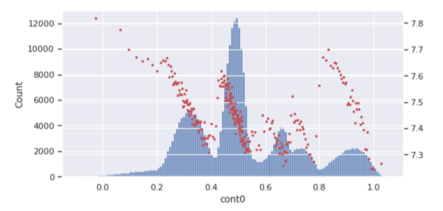

위 차트는 cont0 의 히스토그램과 cont0를 300개의 분위 구간으로 나누어 x값은 분위 구간의 중간값,

y값은 분위 구간에서 target의 평균을 산포도 그래프로 동시에 출력했다.

좌측 y축은 히스토그램의 빈도수이고, 우측 y축은 target의 평균이다.

히스토그램에서 동일한 봉우리 구간 내에서 cont0와 target간에 선형적 관계가 있음이 확인되었다.

이 점을 이용하여 파생 변수를 만들어서 회귀모델을 만들어 간다.

## 단계 4-1

basetable에서 cat0 ~ 9을 첫 번째 범주(알파벳 순)는 제외하고

원핫 인코딩(One-Hot Encoding)하여 prob4데이터셋을 만든다.

```python
# 첫번째 범주는 제외하라고 했으므로 srop_first = True가 필요?
#df_prob4 = pd.get_dummies(df_basetable, columns=cat_cols, srop_first = True)
df_prob4 = pd.get_dummies(df_basetable, columns=cat_cols)
df_prob4.head()
```

| id | cont0 | cont1 | cont2 | cont3 | cont4 | cont5 | cont6 | cont7 | cont8 | cont9 | ... | cat9_F | cat9_G | cat9_H | cat9_I | cat9_J | cat9_K | cat9_L | cat9_M | cat9_N | cat9_O |
| --- | --- | --- | --- | --- | --- | --- | --- | --- | --- | --- | --- | --- | --- | --- | --- | --- | --- | --- | --- | --- | --- |
| 267387 | 0.65226 | 0.55771 | 0.25398 | 0.28196 | 0.82400 | 0.22443 | 0.69220 | 0.30912 | 0.47134 | 0.53290 | ... | 0 | 1 | 0 | 0 | 0 | 0 | 0 | 0 | 0 | 0 |
| 410037 | 0.36970 | 0.68159 | 0.30038 | 0.20156 | 0.46113 | 0.43278 | 0.97199 | 0.62596 | 0.40193 | 0.49181 | ... | 1 | 0 | 0 | 0 | 0 | 0 | 0 | 0 | 0 | 0 |
| 139373 | 0.47881 | 0.63976 | 0.40024 | 0.24153 | 0.27128 | 0.36238 | 0.41310 | 0.27010 | 0.40112 | 0.53052 | ... | 0 | 0 | 0 | 0 | 1 | 0 | 0 | 0 | 0 | 0 |
| 113765 | 0.43438 | 0.77575 | 0.54887 | 0.21935 | 0.27944 | 0.32670 | 0.42301 | 0.28331 | 0.46425 | 0.38302 | ... | 0 | 1 | 0 | 0 | 0 | 0 | 0 | 0 | 0 | 0 |
| 179915 | 0.47866 | 0.64326 | 0.37255 | 0.21004 | 0.41188 | 0.20121 | 0.37466 | 0.46316 | 0.75578 | 0.55676 | ... | 0 | 0 | 0 | 0 | 0 | 0 | 1 | 0 | 0 | 0 |

5 rows × 55 columns

```python
df_prob4.columns
```

```
Index(['cont0', 'cont1', 'cont2', 'cont3', 'cont4', 'cont5', 'cont6', 'cont7',
       'cont8', 'cont9', 'cont10', 'cont11', 'cont12', 'cont13', 'target',
       'targetA', 'cat0_A', 'cat0_B', 'cat1_A', 'cat1_B', 'cat2_A', 'cat2_B',
       'cat3_A', 'cat3_C', 'cat3_D', 'cat4_B', 'cat4_C', 'cat5_A', 'cat5_B',
       'cat5_C', 'cat5_D', 'cat6_A', 'cat6_B', 'cat6_C', 'cat7_B', 'cat7_D',
       'cat7_E', 'cat7_G', 'cat8_A', 'cat8_C', 'cat8_D', 'cat8_E', 'cat8_G',
       'cat9_A', 'cat9_B', 'cat9_F', 'cat9_G', 'cat9_H', 'cat9_I', 'cat9_J',
       'cat9_K', 'cat9_L', 'cat9_M', 'cat9_N', 'cat9_O'],
      dtype='object')
```

```python
'''
아래 코드의 각 라인은 Pandas와 NumPy를 사용하여 데이터프레임의 특정 열에서 더미 컬럼(dum_cols)을 생성하는 과정입니다.
각 줄의 동작을 자세히 설명하면 다음과 같습니다.

### 1. `df_basetable[cat_cols]`
- 동작: `df_basetable`이라는 데이터프레임에서 `cat_cols`에 해당하는 열(컬럼)들만 선택합니다.
- `df_basetable`은 전체 데이터프레임이고, `cat_cols`는 범주형 변수(카테고리형 변수)의 열 이름 리스트로 가정합니다.
    이 부분에서 특정 열들을 추출합니다.
- 출력: `cat_cols`에 해당하는 열들만 포함된 새로운 데이터프레임이 반환됩니다.

### 2. `.apply(lambda x: ['{}_{}'.format(x.name, i) for i in np.sort(x.unique())[1:]])`
- 동작: `apply` 메서드는 선택된 열들에 대해 각 열을 `x`로 받아 `lambda` 함수를 적용합니다.
  - `x.name`: 현재 열의 이름입니다.
  - `x.unique()`: 해당 열에서 중복을 제거한 고유값들을 반환합니다.
  - `np.sort(x.unique())[1:]`: 고유값을 정렬한 후, 첫 번째 요소를 제외한 나머지 요소들로 구성된 배열을 반환합니다.
      이 작업은 더미 변수 생성 시 기준값(예: 원-핫 인코딩의 첫 번째 범주)을 제외하는 데 유용합니다.
  - `['{}_{}'.format(x.name, i) for i in np.sort(x.unique())[1:]]`:
      각 열의 이름과 각 고유값을 결합하여 문자열 리스트를 생성합니다.
      예를 들어, 열 이름이 `color`이고 고유값이 `['red', 'blue', 'green']`이라면,
      `['color_blue', 'color_green']`와 같은 리스트를 생성합니다.
- 출력: 각 열에 대해 생성된 문자열 리스트가 포함된 시리즈가 반환됩니다.

### 3. `.explode()`
- 동작: `explode` 메서드는 리스트나 시리즈의 각 요소를 개별 행으로 확장합니다.
- 출력: 리스트의 각 요소가 행으로 나열된 시리즈가 반환됩니다.
    예를 들어, `['color_blue', 'color_green']`라는 리스트가 하나의 열에 있었다면, 이 리스트는 두 개의 행으로 확장됩니다.

### 4. `.tolist()`
- 동작: `tolist` 메서드는 시리즈를 리스트로 변환합니다.
- 출력: 열 이름과 고유값이 결합된 문자열 리스트가 반환됩니다.

### 5. `np.sort(dum_cols)`
- 동작: `dum_cols` 리스트를 NumPy의 `sort` 메서드를 사용하여 정렬합니다.
- 출력: 문자열 리스트가 알파벳 순으로 정렬됩니다.

### 최종 동작 요약
- 이 코드의 목적은 주어진 범주형 열들에 대해 첫 번째 고유값을 제외한 나머지 고유값을 각 열의 이름과 결합하여
    새로운 문자열 리스트를 만드는 것입니다.
- 그 리스트는 각 고유값에 해당하는 더미 변수의 이름으로 사용할 수 있습니다.
    마지막으로 이 리스트를 알파벳 순으로 정렬합니다.
'''
print('')
```

```python
dum_cols = \
    df_basetable[cat_cols].apply(lambda x: ['{}_{}'.format(x.name, i) for i in np.sort(x.unique())[1:]]).explode().tolist()
np.sort(dum_cols)
```

```
array(['cat0_B', 'cat1_B', 'cat2_B', 'cat3_C', 'cat3_D', 'cat4_C',
       'cat5_B', 'cat5_C', 'cat5_D', 'cat6_B', 'cat6_C', 'cat7_D',
       'cat7_E', 'cat7_G', 'cat8_C', 'cat8_D', 'cat8_E', 'cat8_G',
       'cat9_B', 'cat9_F', 'cat9_G', 'cat9_H', 'cat9_I', 'cat9_J',
       'cat9_K', 'cat9_L', 'cat9_M', 'cat9_N', 'cat9_O'], dtype='<U6')
```